# Breast Cancer Classification with CNN

**Brief description:**  
This notebook presents a custom convolutional neural network (CNN) built from scratch to classify Invasive Ductal Carcinoma (IDC) in breast histopathology images. The project includes comprehensive data preprocessing, addresses class imbalance, and evaluates model performance using key metrics like AUC, precision, and recall. This end-to-end pipeline demonstrates my skills in deep learning for computer vision and in this particular case medical image analysis.

**Author:** Juba Amari  
**Date:** 2025-07-13  
**Context:**  
Developed as a key piece in my apprenticeship search portfolio, showcasing my ability to tackle real-world machine learning and deep learning challenges.

The original dataset is available [here](https://www.kaggle.com/datasets/paultimothymooney/breast-histopathology-images)

And you can check out the evolution of the project on my [Github page](https://github.com/Juba-Amr/breast-cancer-CNN)

**Motivation**

Breast cancer affects millions of women worldwide, and Invasive Ductal Carcinoma (IDC) is its most common and aggressive form. Detecting IDC early can save lives, but analyzing medical images manually is slow and prone to mistakes. Imagine if we could empower doctors with AI tools that quickly and accurately spot cancer signs — helping them make faster, more reliable diagnoses. This project aims to build exactly that: a custom deep learning model to support early IDC detection and make a real difference in healthcare.

**Let's start!** all the data was in an archive with the patients numbers as folders and inside the IDC positive and IDC negatives patches in two separate folders, we take all these out and merge them in 2 folders positive and negative in our destination path.

This section depends on local files and may not run on Colab or your local machine, but if needed, the reader can change the src and dst variables to make this work locally. The src path contains the extracted archive used as a dataset.

```python
import os
import shutil
import numpy as np
import matplotlib.pyplot as plt
import cv2
np.random.seed(42)

src = '../data/raw/'
dst = '../data/clean'

os.makedirs(f'{dst}/0', exist_ok=True)
os.makedirs(f'{dst}/1', exist_ok=True)

for patient_dir in os.listdir(src):
    patient_path = os.path.join(src, patient_dir)
    if not os.path.isdir(patient_path): continue

    zero_dir = os.path.join(patient_path,"0")
    one_dir = os.path.join(patient_path,"1")

    dir_name = os.path.splitext(patient_dir)[0]
    if dir_name.isdigit():
        for file in os.listdir(zero_dir):
            if file not in os.path.join(dst, "0"):
                filepath = os.path.join(zero_dir, file)
                shutil.move(filepath, os.path.join(dst, "0") )


        for file in os.listdir(one_dir):
            if file not in os.path.join(dst, "1"):
                filepath = os.path.join(one_dir, file)
                shutil.move(filepath, os.path.join(dst, "1") )
```

now we can start spliting the data and analizing it

let's get an image

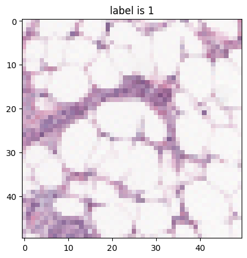

```python
def get_random_image():
    dataset = []
    for label in ["0","1"]:
        folder = os.path.join(dst,label)
        images_path = [os.path.join(folder,f) for f in os.listdir(folder)]
        dataset.extend((path, label) for path in images_path)

    idx = np.random.choice(len(dataset))
    label = dataset[idx][1]
    im = dataset[idx][0]
    im = cv2.imread(im)
    im = cv2.cvtColor(im, cv2.COLOR_BGR2RGB)

    return im, label

def plot_random_image():
    im, label = get_random_image()
    plt.imshow(im)
    plt.title(f"label is {label}")

plot_random_image()
```

Let's now see some random images to get an idea of what our dataset looks like

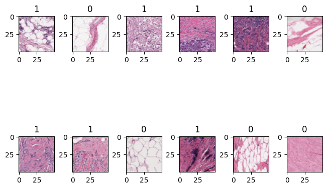

```python
def plot_random_images(num_images=12, dataset = []):
    if len(dataset)==0:
        for label in ["0","1"]:
            folder = os.path.join(dst,label)
            images_path = [os.path.join(folder,f) for f in os.listdir(folder)]
            dataset.extend((path, label) for path in images_path)

    plt.figure(layout='constrained')

    sample = np.random.choice(len(dataset), size=num_images)
    for i,idx in enumerate(sample):
        image_path, label = dataset[idx]
        im = cv2.imread(image_path)
        im_rgb = cv2.cvtColor(im, cv2.COLOR_BGR2RGB)

        plt.subplot(2,num_images//2, i+1)
        plt.imshow(im_rgb)
        plt.title(label)

    plt.show()

plot_random_images()
```

Now we're gonna separate all the images into training, validation and test sets, I've choosen a ratio of 70/15/15 for these, we're gonna have a list of everything and use NumPy's random.shuffle() method to shuffle them to avoid any possible data leak

```python
dataset = []
for label in ["0","1"]:
    folder = os.path.join(dst,label)
    images_path = [os.path.join(folder,f) for f in os.listdir(folder)]
    dataset.extend((path, label) for path in images_path)

pos_dataset=[]
neg_dataset=[]
for name, label in dataset:
    if label=="0":
        neg_dataset.append((name, label))
    else :
        pos_dataset.append((name, label))

train_ratio = 0.7
index_cut_pos = int(len(pos_dataset)*train_ratio)
index_cut_neg = int(len(neg_dataset)*train_ratio)

#print(len(pos_dataset))
#print(len(neg_dataset))


#we shuffle the dataset for more randomness
np.random.shuffle(pos_dataset)
np.random.shuffle(neg_dataset)

X_train_pos = pos_dataset[:index_cut_pos]
X_train_neg = neg_dataset[:index_cut_neg]
X_train = np.concatenate((X_train_pos, X_train_neg))

X_val_pos = pos_dataset[index_cut_pos:]
X_val_neg = neg_dataset[index_cut_neg:]


validation_pos_cut = len(X_val_pos)//2
validation_neg_cut = len(X_val_neg)//2

X_test = np.concatenate([X_val_pos[validation_pos_cut:], X_val_neg[validation_neg_cut:]])
X_val = np.concatenate([X_val_pos[:validation_pos_cut], X_val_neg[:validation_neg_cut]])
```

[output not shown]

```python
#paths
train_path = os.path.join(dst,"train")
val_path = os.path.join(dst, "validation")
test_path = os.path.join(dst, "test")
```

```python
def copy_data(data, destination_path):
    print(f"Copying {data} set with {len(data)} images...")
    for i, (name, label) in enumerate(data):
        #for testing purposes
        #if i>=10000:
        #    break

        x_dir = os.path.join(destination_path,label)
        os.makedirs(x_dir, exist_ok=True)

        filename = os.path.basename(name)
        dst_path = os.path.join(x_dir,filename)
        shutil.copyfile(name,dst_path)

        if i%500==0:
            print(f'{i}/{len(data)} images have been copied')
    print('everything has been copied')

#copy_data(X_train,train_path)
#copy_data(X_val,val_path)
#copy_data(X_test, test_path)
```

Problem : this is a naive approach of randomly distributing patches without taking into account the whole slide, this may cause data leakage as the patches are not independant and the model may see in validation some patches from the same patient seen in training.

As the patches are correlated we will have some overly optimistic results, we will redo the data split, this time spliting by patients, then extracting all positive and negative patches, this may or may not cause some problematic distribution of + and - patches because not all patients have the same number of + patches, and we will adress this problem if we are faced to it.

But as of right now, we prefer avoiding data leakage.

We start by creating a python dictionary where we have patient ids as keys and all their patches in a list as values, these patches are tuples of the form (image, 1 or 0).

```python
patients = {}

for label in ["0", "1"]:
    current_dir = os.path.join(dst, label)

    for patch in os.listdir(current_dir):
        patch_path = os.path.join(current_dir, patch)
        patch_name = os.path.basename(patch)
        id = patch_name.split('_')[0]

        if id not in patients:
            patients[id] = []

        patients[id].append((patch_path, label))

#now we have a dictionary with the patients and their patches
patch_count = {k: len(v) for k, v in patients.items()}
print(f"The number of patiens is {len(patch_count)}")
print(f"the total number of patches is {sum(patch_count.values())}")
print(f"The average number of patches per patient is {sum(patch_count.values())/len(patch_count)}")
```

```
The number of patiens is 279
the total number of patches is 277524
The average number of patches per patient is 994.7096774193549
```

perfect, now we split by patients with that previous 70/15/15 ratio then copy the data using our previous copying function.

```python
def split_data(data, train_ratio=0.7, seed=42):
    np.random.seed(seed)
    patient_ids = list(data.keys())
    np.random.shuffle(patient_ids)
    split_index = int(len(patient_ids)*train_ratio)

    training = set(patient_ids[:split_index])
    val = patient_ids[split_index:]
    test_split_index = len(val)//2
    testing = set(val[test_split_index:])
    val = set(val[:test_split_index])
    #we convert to sets for faster in checks


    X_train = []
    X_val = []
    X_test = []

    for k, v in data.items():
        if k in training:
            X_train.extend(patch for patch in v)
        elif k in val :
            X_val.extend(patch for patch in v)
        else:
            X_test.extend(patch for patch in v)

    return np.array(X_train), np.array(X_val), np.array(X_test)
```

```python
X_train, X_val, X_test = split_data(patients)

copy_data(X_train, train_path)
copy_data(X_val, val_path)
copy_data(X_test, test_path)
```

Here I've cleared the above cell's output for better readability but all the files were in fact copied

Let's verify we have some equal distribution of the positive and negative images between our different folders

```
<class 'int'> <class 'int'> <class 'int'>
<class 'int'> <class 'int'> <class 'int'>
[0 1 2]
```

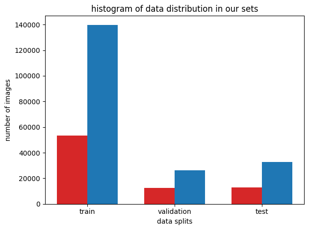

```python
plt.figure(layout='constrained')


train_1 = len(os.listdir(os.path.join(dst,"train/1")))
train_0 = len(os.listdir(os.path.join(dst,"train/0")))
val_1 = len(os.listdir(os.path.join(dst,"validation/1")))
val_0 = len(os.listdir(os.path.join(dst,"validation/0")))
test_1 = len(os.listdir(os.path.join(dst,"test/1")))
test_0 = len(os.listdir(os.path.join(dst,"test/0")))

print(type(train_1), type(val_1), type(test_1))
print(type(train_0), type(val_0), type(test_0))

labels = ['train','validation','test']
x= np.arange(len(labels))
bar_width = 0.35
print(x)

positive_count = [train_1,val_1,test_1]
negative_count = [train_0,val_0,test_0]

plt.bar(x - bar_width/2, positive_count, width=bar_width, color='#d62728' )
plt.bar(x + bar_width/2, negative_count, width=bar_width, color='#1f77b4')

plt.xticks(x, labels)
plt.ylabel('number of images')
plt.xlabel('data splits')
plt.title('histogram of data distribution in our sets')
plt.tight_layout()

plt.show()
```

Some pie charts to better see the proportions, if everything is fine they should all look the same

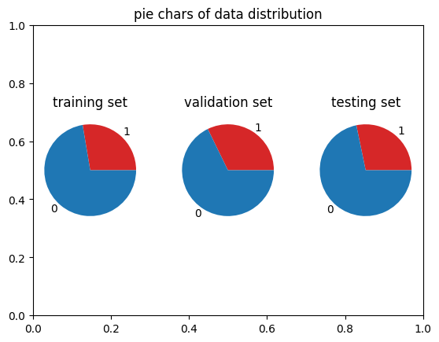

```python
plt.figure()
plt.title('pie chars of data distribution')

plt.subplot(1,3,1)
plt.pie(x=[train_1, train_0], labels=['1','0'], colors=['#d62728', '#1f77b4'])
plt.title('training set')
plt.subplot(1,3,2)
plt.pie(x=[val_1, val_0], labels=['1','0'], colors=['#d62728', '#1f77b4'])
plt.title('validation set')
plt.subplot(1,3,3)
plt.pie(x=[test_1, test_0], labels=['1','0'], colors=['#d62728', '#1f77b4'])
plt.title('testing set')
```

We have about the same proportions in the different folders, so no problem on this side. Now that the data is well organised and splited into the 3 sets we need, we can start building our prediction model, using tensorflow and keras's high level API, we will create our own Convolutional Neural Network architecture from scratch and tweak it until we get the best results.

But before we start model building, we need to preprocess the data we have.

```python
#imports needed
import os
import shutil
import numpy as np
import matplotlib.pyplot as plt
import tensorflow as tf
from tensorflow.keras.preprocessing import image_dataset_from_directory
from tensorflow.keras import layers
import pydot
import graphviz
import pandas as pd
```

```python
#for reproducability
def set_seed(seed=42):
    np.random.seed(seed)
    tf.random.set_seed(seed)
    os.environ['PYTHONHASHSEED'] = str(seed)
    os.environ['TF_DETERMINISTIC_OPS'] = '1'
set_seed()
#because we already organised the data into clear folders, we can directly use this method
X_train = image_dataset_from_directory(
    train_path,
    labels='inferred',
    label_mode='binary',
    color_mode='rgb',
    batch_size=None,
    image_size=(50,50),
    shuffle=True,
    interpolation='nearest'
)

X_val = image_dataset_from_directory(
    val_path,
    labels='inferred',
    label_mode='binary',
    color_mode='rgb',
    batch_size=None,
    image_size=(50,50),
    shuffle=True,
    interpolation='nearest'
)
#autotune for when we map the data
AUTOTUNE = tf.data.experimental.AUTOTUNE
def preprocess(image, label):
    image = tf.image.convert_image_dtype(image, tf.float32) #we normalize the tensors to have them in the interval [0,1]
    return image, label
```

```
Found 193299 files belonging to 2 classes.
Found 38496 files belonging to 2 classes.
```

We check the proportion of positives and negatives to make sure everything was loaded correctly

```python
from collections import Counter

counter = Counter()

for _, label in X_train:
    label_value = int(label.numpy())
    counter[label_value] += 1

print(counter)
```

```
Counter({0: 139851, 1: 53448})
```

A ratio of about 1:2.6, we are dealing with a significant class imbalance, we will take that into account in the class weights of the loss function in order for the model not to get lazy and predict all negatives, our pricipal objective here is a high Recall i.e catching all posives and avoiding false negatives.

Let's now write the data augmentation pipeline, this will help our model generalize quicker but we won't be changing anything linked to the images's colors, brightness, saturation... because it may lose some important information we want to keep, just flips and rotations should do the job.

```python
data_augmentation = tf.keras.Sequential([
    layers.RandomFlip(mode='horizontal_and_vertical'),
    layers.RandomRotation(factor=(-0.3, 0.3)),
]) #we don't alter the colors because on a former try it used to give very optimistic results on training set and poor ones in test

def augmentation(image, label):
    return (data_augmentation(image), label)
```

We can finally preprocess with everything we have defined

```python
print(tf.data.experimental.cardinality(X_train).numpy())
print(tf.data.experimental.cardinality(X_val).numpy())

X_train = (
    X_train
    .map(preprocess, num_parallel_calls=AUTOTUNE, deterministic=True)
    .map(augmentation , num_parallel_calls=AUTOTUNE, deterministic=True)
    .shuffle(buffer_size=1000)
    .batch(32)
    .cache()
    .prefetch(buffer_size=AUTOTUNE)
)
X_val = (
    X_val
    .map(preprocess, num_parallel_calls=AUTOTUNE, deterministic=True)
    .batch(32)
    .cache()
    .prefetch(buffer_size=AUTOTUNE)
)

print(tf.data.experimental.cardinality(X_train).numpy())
print(tf.data.experimental.cardinality(X_val).numpy())
```

```
193299
38496
6041
1203
```

We check some of the images to make sure nothing broke in augmentation

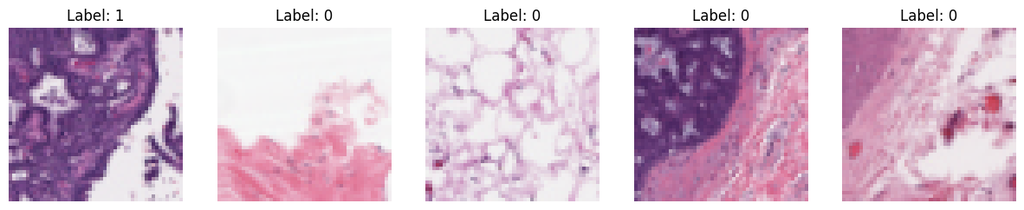

```python
for images, labels in X_train.take(1):
    fig, axes = plt.subplots(1, 5, figsize=(15, 5))
    for i in range(5):
        axes[i].imshow(images[i].numpy())
        axes[i].set_title(f"Label: {int(labels[i].numpy())}")
        axes[i].axis('off')
    plt.show()
```

The data preprocessing is done, now we'll start the model building, first step is feature extraction, then the prediction model.

For feature extraction we will use 3 layers of keras's Conv2D with filters starting at 32, batch normalization, ReLu activation and maximum pooling. (We use GlobalAveragePooling instead of flatten because it gives better results after testing both) Then, the body will have three 64 units dense layers, ending in a sigmoid activation to get a probability.

```python
feature_extraction = [
        #input layer will be size 50x50x3
        layers.Conv2D(input_shape=(50, 50, 3), filters=32, kernel_size=(3,3), strides=1, padding='same', use_bias=False), #50x50x32 for base filters
        layers.BatchNormalization(),
        layers.Activation('relu'),
        layers.MaxPool2D(pool_size=(2,2), strides=None, padding='valid'), #25x25x32

        layers.Conv2D(filters=64, kernel_size=(3,3), use_bias=False), #25x25x64
        layers.BatchNormalization(),
        layers.Activation('relu'),
        layers.MaxPool2D(pool_size=(2,2), strides=None, padding='valid'), #12x12x64

        layers.Conv2D(filters=128, kernel_size=(3,3), use_bias=False), #12x12x128
        layers.BatchNormalization(),
        layers.Activation('relu'),
        layers.MaxPool2D(pool_size=(2,2), strides=None, padding='valid'), #6x6x128

        layers.GlobalAveragePooling2D()
    ]

model_body = [
        layers.Dense(units=64, input_shape=[4608], kernel_regularizer='l2'), #L2 prevents overfitting quickly and makes sure to penalize more the false negatives
        layers.BatchNormalization(), #to stabilize training
        layers.Activation('relu'),
        layers.Dropout(0.5), #after a first test at 30% dropout I noticed it wasn't enought and pushed it to 50%

        layers.Dense(units=64, kernel_regularizer='l2'),
        layers.BatchNormalization(),
        layers.Activation('relu'),
        layers.Dropout(0.5),

        layers.Dense(units=64, kernel_regularizer='l2'),
        layers.BatchNormalization(),
        layers.Activation('relu'),
        layers.Dropout(0.5),

        layers.Dense(units=1, activation='sigmoid')
    ]
```

Now we assemble the model, compile and we can generate a graphical representation.

As a metric to evaluate, Recall is the most important, because we are detecting cancer cases, what we want to avoid the most are false negatives, as the consequences can be very bad while a false positive may only require some more testing.

```python
model = tf.keras.Sequential([
    *feature_extraction,
    *model_body
])

model.compile(
    optimizer='adam',
    loss=tf.keras.losses.BinaryFocalCrossentropy(gamma=2.0, from_logits=False),
    metrics=['binary_accuracy',
            tf.keras.metrics.Recall(name='recall'),
            tf.keras.metrics.Precision(name='precision'),
            tf.keras.metrics.AUC(name='auc')
        ]
)

#we add a callback
early_stopping = tf.keras.callbacks.EarlyStopping(
    monitor= "val_loss",
    min_delta= 0.01,
    patience= 5,
    mode='min',
    restore_best_weights=True,
    start_from_epoch=10
)
```

Here's a quick overview of our model's structure

```python
model.build()
model.summary()
```

```
Model: "sequential_2"
```

```
┏━━━━━━━━━━━━━━━━━━━━━━━━━━━━━━━━━┳━━━━━━━━━━━━━━━━━━━━━━━━┳━━━━━━━━━━━━━━━┓
┃ Layer (type)                    ┃ Output Shape           ┃       Param # ┃
┡━━━━━━━━━━━━━━━━━━━━━━━━━━━━━━━━━╇━━━━━━━━━━━━━━━━━━━━━━━━╇━━━━━━━━━━━━━━━┩
│ conv2d_6 (Conv2D)               │ (None, 50, 50, 32)     │           864 │
├─────────────────────────────────┼────────────────────────┼───────────────┤
│ batch_normalization_12          │ (None, 50, 50, 32)     │           128 │
│ (BatchNormalization)            │                        │               │
├─────────────────────────────────┼────────────────────────┼───────────────┤
│ activation_12 (Activation)      │ (None, 50, 50, 32)     │             0 │
├─────────────────────────────────┼────────────────────────┼───────────────┤
│ max_pooling2d_6 (MaxPooling2D)  │ (None, 25, 25, 32)     │             0 │
├─────────────────────────────────┼────────────────────────┼───────────────┤
│ conv2d_7 (Conv2D)               │ (None, 23, 23, 64)     │        18,432 │
├─────────────────────────────────┼────────────────────────┼───────────────┤
│ batch_normalization_13          │ (None, 23, 23, 64)     │           256 │
│ (BatchNormalization)            │                        │               │
├─────────────────────────────────┼────────────────────────┼───────────────┤
│ activation_13 (Activation)      │ (None, 23, 23, 64)     │             0 │
├─────────────────────────────────┼────────────────────────┼───────────────┤
│ max_pooling2d_7 (MaxPooling2D)  │ (None, 11, 11, 64)     │             0 │
├─────────────────────────────────┼────────────────────────┼───────────────┤
│ conv2d_8 (Conv2D)               │ (None, 9, 9, 128)      │        73,728 │
├─────────────────────────────────┼────────────────────────┼───────────────┤
│ batch_normalization_14          │ (None, 9, 9, 128)      │           512 │
│ (BatchNormalization)            │                        │               │
├─────────────────────────────────┼────────────────────────┼───────────────┤
│ activation_14 (Activation)      │ (None, 9, 9, 128)      │             0 │
├─────────────────────────────────┼────────────────────────┼───────────────┤
│ max_pooling2d_8 (MaxPooling2D)  │ (None, 4, 4, 128)      │             0 │
├─────────────────────────────────┼────────────────────────┼───────────────┤
│ global_average_pooling2d_2      │ (None, 128)            │             0 │
│ (GlobalAveragePooling2D)        │                        │               │
├─────────────────────────────────┼────────────────────────┼───────────────┤
│ dense_8 (Dense)                 │ (None, 64)             │         8,256 │
├─────────────────────────────────┼────────────────────────┼───────────────┤
│ batch_normalization_15          │ (None, 64)             │           256 │
│ (BatchNormalization)            │                        │               │
├─────────────────────────────────┼────────────────────────┼───────────────┤
│ activation_15 (Activation)      │ (None, 64)             │             0 │
├─────────────────────────────────┼────────────────────────┼───────────────┤
│ dropout_6 (Dropout)             │ (None, 64)             │             0 │
├─────────────────────────────────┼────────────────────────┼───────────────┤
│ dense_9 (Dense)                 │ (None, 64)             │         4,160 │
├─────────────────────────────────┼────────────────────────┼───────────────┤
│ batch_normalization_16          │ (None, 64)             │           256 │
│ (BatchNormalization)            │                        │               │
├─────────────────────────────────┼────────────────────────┼───────────────┤
│ activation_16 (Activation)      │ (None, 64)             │             0 │
├─────────────────────────────────┼────────────────────────┼───────────────┤
│ dropout_7 (Dropout)             │ (None, 64)             │             0 │
├─────────────────────────────────┼────────────────────────┼───────────────┤
│ dense_10 (Dense)                │ (None, 64)             │         4,160 │
├─────────────────────────────────┼────────────────────────┼───────────────┤
│ batch_normalization_17          │ (None, 64)             │           256 │
│ (BatchNormalization)            │                        │               │
├─────────────────────────────────┼────────────────────────┼───────────────┤
│ activation_17 (Activation)      │ (None, 64)             │             0 │
├─────────────────────────────────┼────────────────────────┼───────────────┤
│ dropout_8 (Dropout)             │ (None, 64)             │             0 │
├─────────────────────────────────┼────────────────────────┼───────────────┤
│ dense_11 (Dense)                │ (None, 1)              │            65 │
└─────────────────────────────────┴────────────────────────┴───────────────┘
```

```
 Total params: 111,329 (434.88 KB)
```

```
 Trainable params: 110,497 (431.63 KB)
```

```
 Non-trainable params: 832 (3.25 KB)
```

before we fit the model, we will write a callback for saving our model every epoch so we can let the training go and comeback later

```python
os.makedirs("../model/model2/checkpoints", exist_ok=True)

checkpoint = tf.keras.callbacks.ModelCheckpoint(
    "../model/model2/checkpoints/{epoch:02d}-{val_loss:.2f}.keras",
    monitor='val_loss',
    verbose=1,
    save_best_only=False,
    save_weights_only=False,
    save_freq='epoch'
)
```

We can now fit our custom ConvNet !

```python
history = model.fit(
    X_train,
    epochs=60,
    verbose=1,
    callbacks=[early_stopping, checkpoint],
    validation_split=0,
    validation_data=X_val,
    validation_steps=None,
    class_weight={0:1.0, 1:5},
    validation_freq=1
)
```

```
6041/6041 ━━━━━━━━━━━━━━━━━━━━ 0s 320ms/step - auc: 0.8356 - binary_accuracy: 0.7048 - loss: 0.8279 - precision: 0.4841 - recall: 0.8636
Epoch 1: saving model to ../model/model2/checkpoints/01-0.20.keras
6041/6041 ━━━━━━━━━━━━━━━━━━━━ 2012s 332ms/step - auc: 0.8356 - binary_accuracy: 0.7048 - loss: 0.8278 - precision: 0.4841 - recall: 0.8636 - val_auc: 0.8458 - val_binary_accuracy: 0.7508 - val_loss: 0.1985 - val_precision: 0.8356 - val_recall: 0.2828
6041/6041 ━━━━━━━━━━━━━━━━━━━━ 0s 71ms/step - auc: 0.8999 - binary_accuracy: 0.7759 - loss: 0.2323 - precision: 0.5585 - recall: 0.9039
Epoch 2: saving model to ../model/model2/checkpoints/02-0.18.keras
6041/6041 ━━━━━━━━━━━━━━━━━━━━ 442s 73ms/step - auc: 0.8999 - binary_accuracy: 0.7759 - loss: 0.2323 - precision: 0.5585 - recall: 0.9039 - val_auc: 0.8687 - val_binary_accuracy: 0.7629 - val_loss: 0.1800 - val_precision: 0.8488 - val_recall: 0.3220
6040/6041 ━━━━━━━━━━━━━━━━━━━━ 0s 73ms/step - auc: 0.9107 - binary_accuracy: 0.7930 - loss: 0.2189 - precision: 0.5806 - recall: 0.9061
Epoch 3: saving model to ../model/model2/checkpoints/03-0.21.keras
6041/6041 ━━━━━━━━━━━━━━━━━━━━ 452s 75ms/step - auc: 0.9107 - binary_accuracy: 0.7930 - loss: 0.2189 - precision: 0.5806 - recall: 0.9061 - val_auc: 0.8623 - val_binary_accuracy: 0.7921 - val_loss: 0.2089 - val_precision: 0.7898 - val_recall: 0.4841
6040/6041 ━━━━━━━━━━━━━━━━━━━━ 0s 72ms/step - auc: 0.9157 - binary_accuracy: 0.7979 - loss: 0.2118 - precision: 0.5864 - recall: 0.9127
Epoch 4: saving model to ../model/model2/checkpoints/04-0.15.keras
6041/6041 ━━━━━━━━━━━━━━━━━━━━ 445s 74ms/step - auc: 0.9157 - binary_accuracy: 0.7979 - loss: 0.2118 - precision: 0.5864 - recall: 0.9127 - val_auc: 0.8711 - val_binary_accuracy: 0.8154 - val_loss: 0.1517 - val_precision: 0.7624 - val_recall: 0.6209
6040/6041 ━━━━━━━━━━━━━━━━━━━━ 0s 140ms/step - auc: 0.9188 - binary_accuracy: 0.8069 - loss: 0.2078 - precision: 0.5991 - recall: 0.9119
Epoch 5: saving model to ../model/model2/checkpoints/05-0.14.keras
6041/6041 ━━━━━━━━━━━━━━━━━━━━ 856s 142ms/step - auc: 0.9188 - binary_accuracy: 0.8069 - loss: 0.2078 - precision: 0.5991 - recall: 0.9119 - val_auc: 0.8924 - val_binary_accuracy: 0.8194 - val_loss: 0.1385 - val_precision: 0.8213 - val_recall: 0.5622
6040/6041 ━━━━━━━━━━━━━━━━━━━━ 0s 69ms/step - auc: 0.9217 - binary_accuracy: 0.8065 - loss: 0.2038 - precision: 0.5979 - recall: 0.9157
Epoch 6: saving model to ../model/model2/checkpoints/06-0.12.keras
6041/6041 ━━━━━━━━━━━━━━━━━━━━ 428s 71ms/step - auc: 0.9217 - binary_accuracy: 0.8065 - loss: 0.2038 - precision: 0.5979 - recall: 0.9157 - val_auc: 0.8825 - val_binary_accuracy: 0.8235 - val_loss: 0.1225 - val_precision: 0.7305 - val_recall: 0.7172
6041/6041 ━━━━━━━━━━━━━━━━━━━━ 0s 76ms/step - auc: 0.9246 - binary_accuracy: 0.8138 - loss: 0.1999 - precision: 0.6090 - recall: 0.9128
Epoch 7: saving model to ../model/model2/checkpoints/07-0.13.keras
6041/6041 ━━━━━━━━━━━━━━━━━━━━ 474s 78ms/step - auc: 0.9246 - binary_accuracy: 0.8138 - loss: 0.1999 - precision: 0.6090 - recall: 0.9128 - val_auc: 0.8870 - val_binary_accuracy: 0.8264 - val_loss: 0.1341 - val_precision: 0.7441 - val_recall: 0.7036
6040/6041 ━━━━━━━━━━━━━━━━━━━━ 0s 70ms/step - auc: 0.9256 - binary_accuracy: 0.8121 - loss: 0.1995 - precision: 0.6056 - recall: 0.9182
Epoch 8: saving model to ../model/model2/checkpoints/08-0.15.keras
6041/6041 ━━━━━━━━━━━━━━━━━━━━ 437s 72ms/step - auc: 0.9256 - binary_accuracy: 0.8121 - loss: 0.1995 - precision: 0.6056 - recall: 0.9182 - val_auc: 0.8694 - val_binary_accuracy: 0.8148 - val_loss: 0.1470 - val_precision: 0.7406 - val_recall: 0.6550
6040/6041 ━━━━━━━━━━━━━━━━━━━━ 0s 70ms/step - auc: 0.9268 - binary_accuracy: 0.8162 - loss: 0.1981 - precision: 0.6121 - recall: 0.9150
Epoch 9: saving model to ../model/model2/checkpoints/09-0.14.keras
6041/6041 ━━━━━━━━━━━━━━━━━━━━ 439s 73ms/step - auc: 0.9268 - binary_accuracy: 0.8162 - loss: 0.1981 - precision: 0.6121 - recall: 0.9150 - val_auc: 0.8802 - val_binary_accuracy: 0.8252 - val_loss: 0.1382 - val_precision: 0.8082 - val_recall: 0.6005
6040/6041 ━━━━━━━━━━━━━━━━━━━━ 0s 74ms/step - auc: 0.9278 - binary_accuracy: 0.8179 - loss: 0.1966 - precision: 0.6142 - recall: 0.9178
Epoch 10: saving model to ../model/model2/checkpoints/10-0.16.keras
6041/6041 ━━━━━━━━━━━━━━━━━━━━ 462s 76ms/step - auc: 0.9278 - binary_accuracy: 0.8179 - loss: 0.1966 - precision: 0.6142 - recall: 0.9178 - val_auc: 0.8843 - val_binary_accuracy: 0.8252 - val_loss: 0.1569 - val_precision: 0.7670 - val_recall: 0.6576
6041/6041 ━━━━━━━━━━━━━━━━━━━━ 0s 81ms/step - auc: 0.9300 - binary_accuracy: 0.8219 - loss: 0.1938 - precision: 0.6198 - recall: 0.9201
Epoch 11: saving model to ../model/model2/checkpoints/11-0.15.keras
6041/6041 ━━━━━━━━━━━━━━━━━━━━ 502s 83ms/step - auc: 0.9300 - binary_accuracy: 0.8219 - loss: 0.1938 - precision: 0.6198 - recall: 0.9201 - val_auc: 0.8405 - val_binary_accuracy: 0.7950 - val_loss: 0.1550 - val_precision: 0.7119 - val_recall: 0.6121
6041/6041 ━━━━━━━━━━━━━━━━━━━━ 0s 76ms/step - auc: 0.9310 - binary_accuracy: 0.8226 - loss: 0.1925 - precision: 0.6209 - recall: 0.9203
Epoch 12: saving model to ../model/model2/checkpoints/12-0.17.keras
6041/6041 ━━━━━━━━━━━━━━━━━━━━ 476s 79ms/step - auc: 0.9310 - binary_accuracy: 0.8226 - loss: 0.1925 - precision: 0.6209 - recall: 0.9203 - val_auc: 0.8710 - val_binary_accuracy: 0.8151 - val_loss: 0.1739 - val_precision: 0.7884 - val_recall: 0.5833
```

[output cut: 18 more lines]

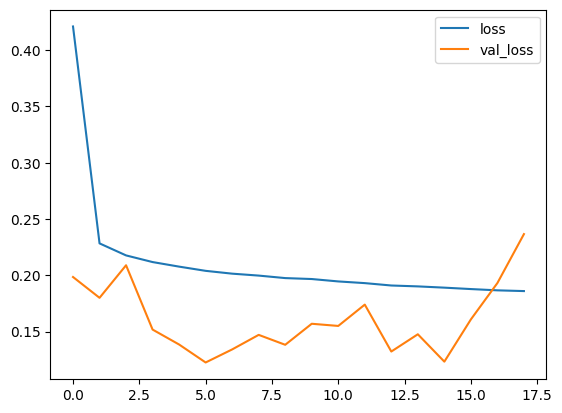

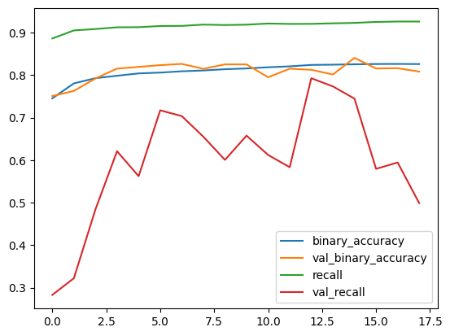

```python
history_df = pd.DataFrame(history.history)
history_df.loc[:, ['loss', 'val_loss']].plot()
history_df.loc[:, ['binary_accuracy', 'val_binary_accuracy', 'recall', 'val_recall']].plot()
```

So, we started to overfit at about epoch 13, our early stopping then stopped the training, the curves look good but not incredible. We may now evaluate the model on testing data to see its live performance.

```python
X_test = image_dataset_from_directory(
    test_path,
    labels='inferred',
    label_mode='binary',
    color_mode='rgb',
    image_size=(50,50),
    batch_size=None,
    shuffle=True,
    interpolation='nearest'
)

X_test = (
    X_test
    .map(preprocess, num_parallel_calls=AUTOTUNE, deterministic=True)
    .batch(64)
    .cache()
    .prefetch(AUTOTUNE)
)
```

```
Found 45729 files belonging to 2 classes.
```

```python
model = tf.keras.models.load_model('../model/model2/checkpoints/18-0.24.keras')
```

```python
test_history = model.evaluate(
    X_test,
    batch_size=None,
    verbose=1,
    steps=None,
    return_dict=True
)
```

```
715/715 ━━━━━━━━━━━━━━━━━━━━ 95s 133ms/step - auc: 0.8887 - binary_accuracy: 0.8114 - loss: 0.1362 - precision: 0.6256 - recall: 0.8251
```

We may later want to change our threshold for maximizing recall while minimizing the loss in precision, as recall is the most important metric for us here

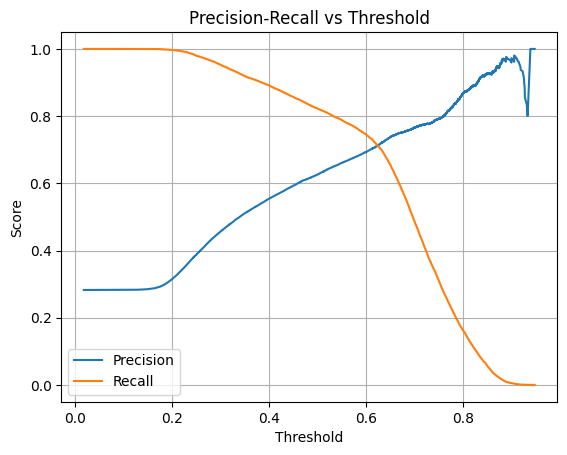

```python
from sklearn.metrics import precision_recall_curve
y_true = []
y_score = []

for images, labels in X_test:
    probs = model.predict(images, verbose=0)
    y_score.extend(probs.flatten())
    y_true.extend(labels.numpy().flatten())

y_true = np.array(y_true)
y_score = np.array(y_score)

precision, recall, thresholds = precision_recall_curve(y_true, y_score)

plt.figure()
plt.plot(thresholds, precision[:-1], label='Precision')
plt.plot(thresholds, recall[:-1], label='Recall')
plt.xlabel('Threshold')
plt.ylabel('Score')
plt.title('Precision-Recall vs Threshold')
plt.legend()
plt.grid(True)
plt.show()
```

As we see here a good threshold would around 0.65, but we can make an even better model, this one seems to overcompensate with the weight classes, we'll do some adjustments, put the class_weight at {0:1, 1:4.2}, halve the batch size for training to maybe achieve better generalization, change the minimum variation of our early stoping to give the model more time to converge if needed and add a callback to make it easier to escape early plateau's.

We will continue all this on Google Colab for faster training because we have access to GPU acceleration, so some file paths may change in the next part of this notebook because I am merging both notebooks at the end.